# Capstone Project Pitch

2022-10-11

## Text predictor algorithms

Modern keyboards have built-in text predictor algorithms in order to ease the writing process of the user. Besides, these algorithms are also used in a variety of industries.

The objective of the Capstone Project is to predict the next word based on the preceding word(s) using a large text dataset collected from Twitter, blogs, and news (raw data: https://d396qusza40orc.cloudfront.net/dsscapstone/dataset/Coursera-SwiftKey.zip.

## The Backoff with Relative Frequencies (1/2)

The algorithm developed makes use of the Backoff with Relative Frequencies or “Stupid” Backoff method. The model uses N-gram data, from bigrams to pentagrams, to assign a score to each potential prediction, which is penalised depending on the N-gram data used. The mathematical description can be seen below, where \(f\) is the frequency, \(w\) is the word and \(S\) is the score (*Brants et al, 2007*).

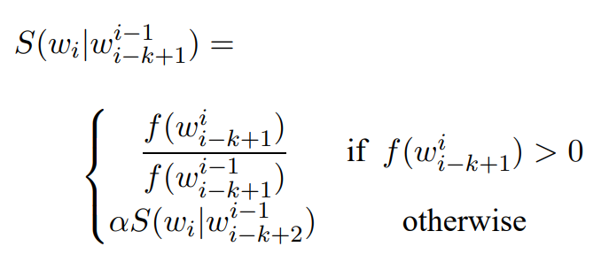

## The Backoff with Relative Frequencies (2/2)

In short:

1. Words and frequencies are added to the N-gram data.
2. For the highest possible order N-gram data (pentagram), a score is assigned to each prediction based on the previous word frequencies as shown in the previous slide.
3. For predictions stemming from N-gram data of decreasing order, the same is done, but the score is penalised via multiplying it by 0.4.

## Shiny app

The Shiny app that enables the use of the algorithm is fairly straightforward. It can be accessed here: https://sgb67.shinyapps.io/Capstone-Project/.

It takes the text input (2 words or more) in the side panel, together with the number of predictions desired. In the main panel, a table of the top predictors along with their scores is shown.